# MovieLens Project_Vijay

### `Project - MovieLens Data Analysis`

The GroupLens Research Project is a research group in the Department of Computer Science and Engineering at the University of Minnesota. The data is widely used for collaborative filtering and other filtering solutions. However, we will be using this data to act as a means to demonstrate our skill in using Python to “play” with data.

### `Objective:`

- To implement the techniques learnt as a part of the course.

### `Learning Outcomes:`

- Exploratory Data Analysis
- Visualization using Python
- Pandas – groupby, merging

### `Domain`

- Internet and Entertainment

**Note that the project will need you to apply the concepts of groupby and merging extensively.**

### `Datasets Information:`

*rating.csv:* It contains information on ratings given by the users to a particular movie.

- user id: id assigned to every user
- movie id: id assigned to every movie
- rating: rating given by the user
- timestamp: Time recorded when the user gave a rating

*movie.csv:* File contains information related to the movies and their genre.

- movie id: id assigned to every movie
- movie title: Title of the movie
- release date: Date of release of the movie
- Action: Genre containing binary values (1 - for action 0 - not action)
- Adventure: Genre containing binary values (1 - for adventure 0 - not adventure)
- Animation: Genre containing binary values (1 - for animation 0 - not animation)
- Children’s: Genre containing binary values (1 - for children's 0 - not children's)
- Comedy: Genre containing binary values (1 - for comedy 0 - not comedy)
- Crime: Genre containing binary values (1 - for crime 0 - not crime)
- Documentary: Genre containing binary values (1 - for documentary 0 - not documentary)
- Drama: Genre containing binary values (1 - for drama 0 - not drama)
- Fantasy: Genre containing binary values (1 - for fantasy 0 - not fantasy)
- Film-Noir: Genre containing binary values (1 - for film-noir 0 - not film-noir)
- Horror: Genre containing binary values (1 - for horror 0 - not horror)
- Musical: Genre containing binary values (1 - for musical 0 - not musical)
- Mystery: Genre containing binary values (1 - for mystery 0 - not mystery)
- Romance: Genre containing binary values (1 - for romance 0 - not romance)
- Sci-Fi: Genre containing binary values (1 - for sci-fi 0 - not sci-fi)
- Thriller: Genre containing binary values (1 - for thriller 0 - not thriller)
- War: Genre containing binary values (1 - for war 0 - not war)
- Western: Genre containing binary values (1 - for western - not western)

*user.csv:* It contains information of the users who have rated the movies.

- user id: id assigned to every user
- age: Age of the user
- gender: Gender of the user
- occupation: Occupation of the user
- zip code: Zip code of the use

**`Please provide you insights wherever necessary.`**

### 1. Import the necessary packages - 2.5 marks

```python
import numpy as np
import pandas as pd
import matplotlib.pyplot as plt
import matplotlib.figure as figure
import seaborn as sns
```

### 2. Read the 3 datasets into dataframes - 2.5 marks

```python
#reading data frames from a csv file.
ratings = pd.read_csv('Data.csv')
movies = pd.read_csv('item.csv')
users = pd.read_csv('user.csv')
```

### 3. Apply info, shape, describe, and find the number of missing values in the data - 5 marks

- Note that you will need to do it for all the three datasets seperately

```python
# Applying info, shape, describe, finding missing values in the data

ratings.info()
ratings.shape
ratings.describe()
ratings.isna().sum()
```

```
<class 'pandas.core.frame.DataFrame'>
RangeIndex: 100000 entries, 0 to 99999
Data columns (total 4 columns):
 #   Column     Non-Null Count   Dtype
---  ------     --------------   -----
 0   user id    100000 non-null  int64
 1   movie id   100000 non-null  int64
 2   rating     100000 non-null  int64
 3   timestamp  100000 non-null  int64
dtypes: int64(4)
memory usage: 3.1 MB
```

```
user id      0
movie id     0
rating       0
timestamp    0
dtype: int64
```

```python
# Applying info, shape, describe, finding missing values in the data

movies.info()
movies.shape
movies.describe()
movies.isna().sum()
```

```
<class 'pandas.core.frame.DataFrame'>
RangeIndex: 1681 entries, 0 to 1680
Data columns (total 22 columns):
 #   Column        Non-Null Count  Dtype
---  ------        --------------  -----
 0   movie id      1681 non-null   int64
 1   movie title   1681 non-null   object
 2   release date  1681 non-null   object
 3   unknown       1681 non-null   int64
 4   Action        1681 non-null   int64
 5   Adventure     1681 non-null   int64
 6   Animation     1681 non-null   int64
 7   Childrens     1681 non-null   int64
 8   Comedy        1681 non-null   int64
 9   Crime         1681 non-null   int64
 10  Documentary   1681 non-null   int64
 11  Drama         1681 non-null   int64
 12  Fantasy       1681 non-null   int64
 13  Film-Noir     1681 non-null   int64
 14  Horror        1681 non-null   int64
 15  Musical       1681 non-null   int64
 16  Mystery       1681 non-null   int64
 17  Romance       1681 non-null   int64
 18  Sci-Fi        1681 non-null   int64
 19  Thriller      1681 non-null   int64
 20  War           1681 non-null   int64
 21  Western       1681 non-null   int64
dtypes: int64(20), object(2)
memory usage: 289.0+ KB
```

```
movie id        0
movie title     0
release date    0
unknown         0
Action          0
Adventure       0
Animation       0
Childrens       0
Comedy          0
Crime           0
Documentary     0
Drama           0
Fantasy         0
Film-Noir       0
Horror          0
Musical         0
Mystery         0
Romance         0
Sci-Fi          0
Thriller        0
War             0
Western         0
dtype: int64
```

```python
# Applying info, shape, describe, finding missing values in the data

users.info()
users.shape
users.describe()
users.isna().sum()
```

```
<class 'pandas.core.frame.DataFrame'>
RangeIndex: 943 entries, 0 to 942
Data columns (total 5 columns):
 #   Column      Non-Null Count  Dtype
---  ------      --------------  -----
 0   user id     943 non-null    int64
 1   age         943 non-null    int64
 2   gender      943 non-null    object
 3   occupation  943 non-null    object
 4   zip code    943 non-null    object
dtypes: int64(2), object(3)
memory usage: 37.0+ KB
```

```
user id       0
age           0
gender        0
occupation    0
zip code      0
dtype: int64
```

### 4. Find the number of movies per genre using the item data - 2.5 marks

```python
#calcutaing number of movies per genre

movies.iloc[:, -19:-1].sum(axis=0)
```

```
unknown          1
Action         251
Adventure      135
Animation       42
Childrens      122
Comedy         505
Crime          109
Documentary     50
Drama          725
Fantasy         22
Film-Noir       24
Horror          92
Musical         56
Mystery         61
Romance        247
Sci-Fi         101
Thriller       251
War             71
dtype: int64
```

### 5. Drop the movie where the genre is unknown - 2.5 marks

```python
# droping movie with unkown genre

movies = movies[movies['unknown']==0]
movies
```

|  | movie id | movie title | release date | unknown | Action | Adventure | Animation | Childrens | Comedy | Crime | ... | Fantasy | Film-Noir | Horror | Musical | Mystery | Romance | Sci-Fi | Thriller | War | Western |
| --- | --- | --- | --- | --- | --- | --- | --- | --- | --- | --- | --- | --- | --- | --- | --- | --- | --- | --- | --- | --- | --- |
| 0 | 1 | Toy Story | 01-Jan-1995 | 0 | 0 | 0 | 1 | 1 | 1 | 0 | ... | 0 | 0 | 0 | 0 | 0 | 0 | 0 | 0 | 0 | 0 |
| 1 | 2 | GoldenEye | 01-Jan-1995 | 0 | 1 | 1 | 0 | 0 | 0 | 0 | ... | 0 | 0 | 0 | 0 | 0 | 0 | 0 | 1 | 0 | 0 |
| 2 | 3 | Four Rooms | 01-Jan-1995 | 0 | 0 | 0 | 0 | 0 | 0 | 0 | ... | 0 | 0 | 0 | 0 | 0 | 0 | 0 | 1 | 0 | 0 |
| 3 | 4 | Get Shorty | 01-Jan-1995 | 0 | 1 | 0 | 0 | 0 | 1 | 0 | ... | 0 | 0 | 0 | 0 | 0 | 0 | 0 | 0 | 0 | 0 |
| 4 | 5 | Copycat | 01-Jan-1995 | 0 | 0 | 0 | 0 | 0 | 0 | 1 | ... | 0 | 0 | 0 | 0 | 0 | 0 | 0 | 1 | 0 | 0 |
| ... | ... | ... | ... | ... | ... | ... | ... | ... | ... | ... | ... | ... | ... | ... | ... | ... | ... | ... | ... | ... | ... |
| 1676 | 1678 | Mat' i syn | 06-Feb-1998 | 0 | 0 | 0 | 0 | 0 | 0 | 0 | ... | 0 | 0 | 0 | 0 | 0 | 0 | 0 | 0 | 0 | 0 |
| 1677 | 1679 | B. Monkey | 06-Feb-1998 | 0 | 0 | 0 | 0 | 0 | 0 | 0 | ... | 0 | 0 | 0 | 0 | 0 | 1 | 0 | 1 | 0 | 0 |
| 1678 | 1680 | Sliding Doors | 01-Jan-1998 | 0 | 0 | 0 | 0 | 0 | 0 | 0 | ... | 0 | 0 | 0 | 0 | 0 | 1 | 0 | 0 | 0 | 0 |
| 1679 | 1681 | You So Crazy | 01-Jan-1994 | 0 | 0 | 0 | 0 | 0 | 1 | 0 | ... | 0 | 0 | 0 | 0 | 0 | 0 | 0 | 0 | 0 | 0 |
| 1680 | 1682 | Scream of Stone (Schrei aus Stein) | 08-Mar-1996 | 0 | 0 | 0 | 0 | 0 | 0 | 0 | ... | 0 | 0 | 0 | 0 | 0 | 0 | 0 | 0 | 0 | 0 |

1680 rows × 22 columns

### 6. Find the movies that have more than one genre - 5 marks

hint: use sum on the axis = 1

Display movie name, number of genres for the movie in dataframe

and also print(total number of movies which have more than one genres)

```python
# calculating number of genre for each movie.
movies['number of genres'] = movies.iloc[:, -20:-1].sum(axis=1)
# printing movie title and number of genre
print(movies[['movie title','number of genres']])
#filtering movies with more than 1 genre
print(movies[['movie title']].where(movies['number of genres'] > 1).count())
```

```
                              movie title  number of genres
0                              Toy Story                  3
1                              GoldenEye                  3
2                             Four Rooms                  1
3                             Get Shorty                  3
4                                Copycat                  3
...                                   ...               ...
1676                          Mat' i syn                  1
1677                           B. Monkey                  2
1678                       Sliding Doors                  2
1679                        You So Crazy                  1
1680  Scream of Stone (Schrei aus Stein)                  1

[1680 rows x 2 columns]
movie title    845
dtype: int64
```

### 7. Univariate plots of columns: 'rating', 'Age', 'release year', 'Gender' and 'Occupation' - 10 marks

*HINT: Use distplot for age. Use lineplot or countplot for release year.*

*HINT: Plot percentages in y-axis and categories in x-axis for ratings, gender and occupation*

*HINT: Please refer to the below snippet to understand how to get to release year from release date. You can use str.split() as depicted below or you could convert it to pandas datetime format and extract year (.dt.year)*

```python
a = 'My*cat*is*brown'
print(a.split('*')[3])

#similarly, the release year needs to be taken out from release date

#also you can simply slice existing string to get the desired data, if we want to take out the colour of the cat

print(a[10:])
print(a[-5:])
```

```
brown
brown
brown
```

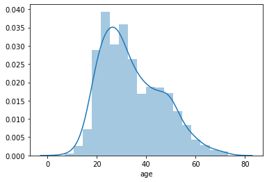

```python
sns.distplot(users['age'])
```

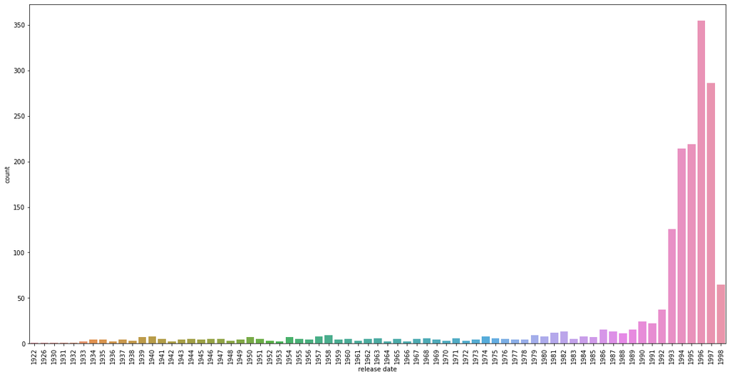

```python
# movies['release year']= movies['release date'].str.split('-').str[2]
plt.figure(figsize=(20,10))
plt.xticks(rotation=90)
sns.countplot(movies['release date'].str.split('-').str[2])
```

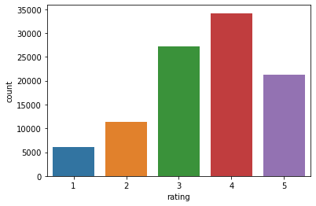

```python
sns.countplot(ratings['rating'])
```

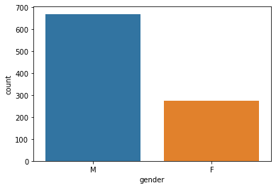

```python
sns.countplot(users['gender'])
```

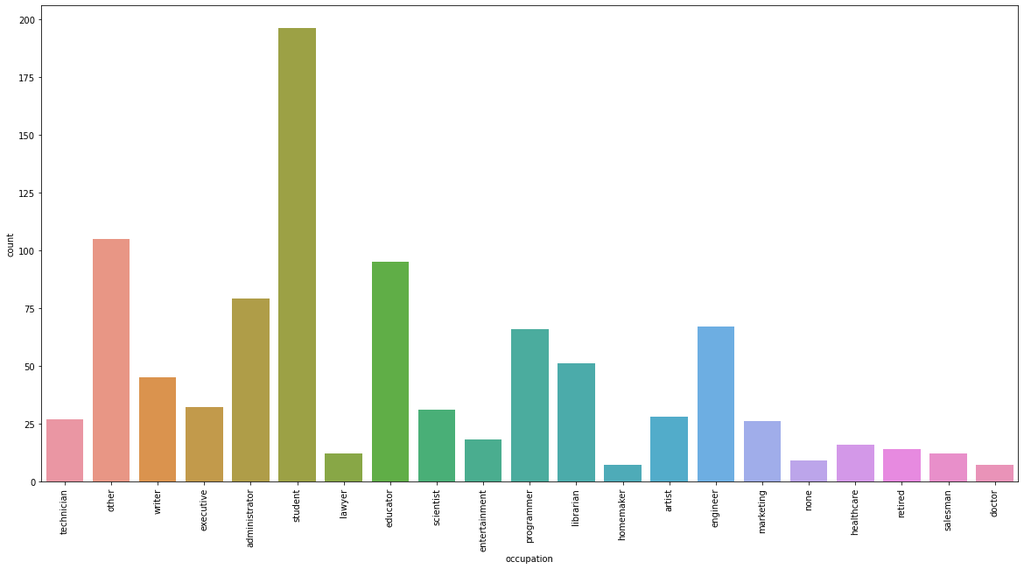

```python
plt.figure(figsize=(20,10))
plt.xticks(rotation=90)
sns.countplot(users['occupation'])
```

### 8. Visualize how popularity of genres has changed over the years - 10 marks

Note that you need to use the **percent of number of releases in a year** as a parameter of popularity of a genre

Hint 1: You need to reach to a data frame where the release year is the index and the genre is the column names (one cell shows the number of release in a year in one genre) or vice versa. (Drop unnecessary column if there are any)

Hint 2: Find the total number of movies release in a year(use `sum(axis=1)` store that value in a new column as 'total'). Now divide the value of each genre in that year by total to get percentage number of release in a particular year. `(df.div(df['total'], axis= 0) * 100)`

Once that is achieved, you can either use univariate plots or can use the heatmap to visualise all the changes over the years in one go.

Hint 3: Use groupby on the relevant column and use sum() on the same to find out the number of releases in a year/genre.

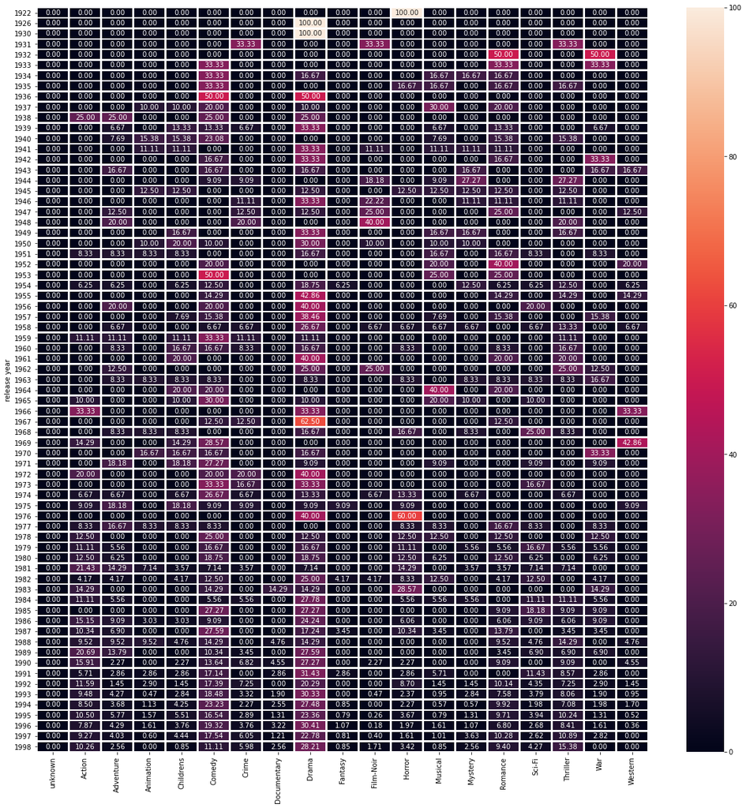

```python
# calulating release year
movies['release year']= movies['release date'].str.split('-').str[2]
#calculting sum of all genre
grouped_df = movies.groupby(['release year']).sum()[['unknown','Action','Adventure','Animation','Childrens','Comedy','Crime','Documentary','Drama','Fantasy','Film-Noir','Horror','Musical','Mystery','Romance','Sci-Fi','Thriller','War','Western']]
grouped_df['total'] = grouped_df.sum(axis=1)
#calculating percentage of movies relases per genre each year
percent_df = (grouped_df.div(grouped_df['total'], axis= 0) * 100)
#dropping total count from dataframe
percent_df.drop(['total'],axis=1,inplace=True)
# plotting using heat map.
plt.figure(figsize=(20,20))
plt.xticks(rotation=90)
sns.heatmap(percent_df, annot=True, linewidths=1.5, fmt= '.2f')
```

### 9. Find the top 25 movies according to average ratings such that each movie has number of ratings more than 100 - 10 marks

Hints :

1. Find the count of ratings and average ratings for every movie.
2. Slice the movies which have ratings more than 100.
3. Sort values according to average rating such that movie which highest rating is on top.
4. Select top 25 movies.
5. You will have to use the .merge() function to get the movie titles.

Note: This question will need you to research about groupby and apply your findings. You can find more on groupby on https://realpython.com/pandas-groupby/.

```python
#Data frame operations

#combining movies and ratings dataframes
movie_ratings = (movies.merge(ratings,on=['movie id']))[['rating','movie title']]

#calculating mean and count of all the ratings by movie
movie_ratings = movie_ratings.groupby('movie title').agg({'rating': ['mean', 'count']})
movie_ratings.columns = ['rating_mean', 'rating_count']

#filtering movies with more than 100 rating count and fetching top 25 movies based on avg rating.
movie_ratings[movie_ratings['rating_count']>100].sort_values('rating_mean',ascending=False).head(25)
```

| movie title | rating_mean | rating_count |
| --- | --- | --- |
| Close Shave, A | 4.491071 | 112 |
| Schindler's List | 4.466443 | 298 |
| Wrong Trousers, The | 4.466102 | 118 |
| Casablanca | 4.456790 | 243 |
| Shawshank Redemption, The | 4.445230 | 283 |
| Rear Window | 4.387560 | 209 |
| Usual Suspects, The | 4.385768 | 267 |
| Star Wars | 4.358491 | 583 |
| 12 Angry Men | 4.344000 | 125 |
| Citizen Kane | 4.292929 | 198 |
| To Kill a Mockingbird | 4.292237 | 219 |
| One Flew Over the Cuckoo's Nest | 4.291667 | 264 |
| Silence of the Lambs, The | 4.289744 | 390 |
| North by Northwest | 4.284916 | 179 |
| Godfather, The | 4.283293 | 413 |
| Secrets & Lies | 4.265432 | 162 |
| Good Will Hunting | 4.262626 | 198 |
| Manchurian Candidate, The | 4.259542 | 131 |
| Dr. Strangelove or: How I Learned to Stop Worrying and Love the Bomb | 4.252577 | 194 |
| Raiders of the Lost Ark | 4.252381 | 420 |
| Vertigo | 4.251397 | 179 |
| Titanic | 4.245714 | 350 |
| Lawrence of Arabia | 4.231214 | 173 |
| Maltese Falcon, The | 4.210145 | 138 |
| Empire Strikes Back, The | 4.204360 | 367 |

### 10. See gender distribution across different genres check for the validity of the below statements - 10 marks

- Men watch more drama than women
- Women watch more Sci-Fi than men
- Men watch more Romance than women

**compare the percentages**

1. Merge all the datasets
2. There is no need to conduct statistical tests around this. Just **compare the percentages** and comment on the validity of the above statements.
3. you might want ot use the .sum(), .div() function here.
4. Use number of ratings to validate the numbers. For example, if out of 4000 ratings received by women, 3000 are for drama, we will assume that 75% of the women watch drama.

```python
#Data frame operations

#Combining all three datasets
merged_df = (movies.merge(ratings,on=['movie id']).merge(users,on=['user id']))   #[['rating','age','release date','gender','occupation']]

#calculting sum on all the genre and count of gender
sum_df = merged_df.groupby('gender').sum()
sum_df['gender_count'] = merged_df.groupby('gender').agg({'gender': ['count']})

#Calcuating percentages
percent_df = sum_df.div(sum_df['gender_count'],axis=0)*100
percent_df
```

| gender | movie id | unknown | Action | Adventure | Animation | Childrens | Comedy | Crime | Documentary | Drama | ... | Sci-Fi | Thriller | War | Western | number of genres | user id | rating | timestamp | age | gender_count |
| --- | --- | --- | --- | --- | --- | --- | --- | --- | --- | --- | --- | --- | --- | --- | --- | --- | --- | --- | --- | --- | --- |
| F | 44497.027741 | 0.0 | 21.143834 | 12.203745 | 3.865879 | 8.672002 | 31.346647 | 6.970239 | 0.726552 | 42.769446 | ... | 10.214469 | 19.760665 | 8.504934 | 1.441448 | 207.203357 | 47501.095656 | 353.150983 | 8.838516e+10 | 3231.482633 | 100.0 |
| M | 41879.803911 | 0.0 | 27.133276 | 14.291871 | 3.515057 | 6.666487 | 29.310995 | 8.432096 | 0.769003 | 38.904003 | ... | 13.603674 | 22.606798 | 9.708829 | 1.997253 | 211.982169 | 45816.483058 | 352.933254 | 8.834180e+10 | 3319.765124 | 100.0 |

2 rows × 26 columns

```python
percent_df['Drama']

# As per the data "Men watch more drama than women" is a false statement.
```

```
gender
F    42.769446
M    38.904003
Name: Drama, dtype: float64
```

```python
percent_df['Sci-Fi']

# As per the data "Women watch more Sci-Fi than men" is a false statement.
```

```
gender
F    10.214469
M    13.603674
Name: Sci-Fi, dtype: float64
```

```python
percent_df['Romance']
# As per the data "Men watch more Romance than women" is a false statement.
```

```
gender
F    22.760121
M    18.320045
Name: Romance, dtype: float64
```